# Risk Factor Analysis

## Outcome Variable

**Outcome Variable:** whz

## Predictor Variables

**Intervention Variable:** meducyrs

**Adjustment Set:**

- arm
- W_mage
- feducyrs
- hhwealth_quart
- W_mhtcm
- W_mwtkg
- W_mbmi
- W_gagebrth
- W_birthwt
- W_birthlen
- single
- W_nrooms
- impsan
- delta_W_mage
- delta_feducyrs
- delta_hhwealth_quart
- delta_W_mhtcm
- delta_W_mwtkg
- delta_W_mbmi
- delta_W_gagebrth
- delta_W_birthwt
- delta_W_birthlen
- delta_single
- delta_W_nrooms
- delta_impsan

## Stratifying Variables

The analysis was stratified on these variable(s):

- agecat
- studyid
- country

## Data Summary

| agecat | studyid | country | meducyrs | n_cell | n |
| --- | --- | --- | --- | --- | --- |
| Birth | ki0047075b-MAL-ED | BANGLADESH | High | 64 | 175 |
| Birth | ki0047075b-MAL-ED | BANGLADESH | Low | 60 | 175 |
| Birth | ki0047075b-MAL-ED | BANGLADESH | Medium | 51 | 175 |
| Birth | ki0047075b-MAL-ED | BRAZIL | High | 18 | 62 |
| Birth | ki0047075b-MAL-ED | BRAZIL | Low | 17 | 62 |
| Birth | ki0047075b-MAL-ED | BRAZIL | Medium | 27 | 62 |
| Birth | ki0047075b-MAL-ED | INDIA | High | 8 | 38 |
| Birth | ki0047075b-MAL-ED | INDIA | Low | 18 | 38 |
| Birth | ki0047075b-MAL-ED | INDIA | Medium | 12 | 38 |
| Birth | ki0047075b-MAL-ED | NEPAL | High | 5 | 24 |
| Birth | ki0047075b-MAL-ED | NEPAL | Low | 12 | 24 |
| Birth | ki0047075b-MAL-ED | NEPAL | Medium | 7 | 24 |
| Birth | ki0047075b-MAL-ED | PERU | High | 65 | 228 |
| Birth | ki0047075b-MAL-ED | PERU | Low | 83 | 228 |
| Birth | ki0047075b-MAL-ED | PERU | Medium | 80 | 228 |
| Birth | ki0047075b-MAL-ED | SOUTH AFRICA | High | 35 | 120 |
| Birth | ki0047075b-MAL-ED | SOUTH AFRICA | Low | 59 | 120 |
| Birth | ki0047075b-MAL-ED | SOUTH AFRICA | Medium | 26 | 120 |
| Birth | ki0047075b-MAL-ED | TANZANIA, UNITED REPUBLIC OF | High | 7 | 97 |
| Birth | ki0047075b-MAL-ED | TANZANIA, UNITED REPUBLIC OF | Low | 32 | 97 |
| Birth | ki0047075b-MAL-ED | TANZANIA, UNITED REPUBLIC OF | Medium | 58 | 97 |
| Birth | ki1000108-CMC-V-BCS-2002 | INDIA | High | 49 | 86 |
| Birth | ki1000108-CMC-V-BCS-2002 | INDIA | Low | 15 | 86 |
| Birth | ki1000108-CMC-V-BCS-2002 | INDIA | Medium | 22 | 86 |
| Birth | ki1000108-IRC | INDIA | High | 101 | 343 |
| Birth | ki1000108-IRC | INDIA | Low | 126 | 343 |
| Birth | ki1000108-IRC | INDIA | Medium | 116 | 343 |
| Birth | ki1000109-EE | PAKISTAN | High | 5 | 177 |
| Birth | ki1000109-EE | PAKISTAN | Low | 156 | 177 |
| Birth | ki1000109-EE | PAKISTAN | Medium | 16 | 177 |

[output cut: 183 more lines]

The following strata were considered:

- agecat: 24 months, studyid: ki0047075b-MAL-ED, country: BANGLADESH
- agecat: 24 months, studyid: ki0047075b-MAL-ED, country: BRAZIL
- agecat: 24 months, studyid: ki0047075b-MAL-ED, country: INDIA
- agecat: 24 months, studyid: ki0047075b-MAL-ED, country: NEPAL
- agecat: 24 months, studyid: ki0047075b-MAL-ED, country: PERU
- agecat: 24 months, studyid: ki0047075b-MAL-ED, country: SOUTH AFRICA
- agecat: 24 months, studyid: ki0047075b-MAL-ED, country: TANZANIA, UNITED REPUBLIC OF
- agecat: 24 months, studyid: ki1000108-CMC-V-BCS-2002, country: INDIA
- agecat: 24 months, studyid: ki1000108-IRC, country: INDIA
- agecat: 24 months, studyid: ki1000109-EE, country: PAKISTAN
- agecat: 24 months, studyid: ki1017093-NIH-Birth, country: BANGLADESH
- agecat: 24 months, studyid: ki1017093b-PROVIDE, country: BANGLADESH
- agecat: 24 months, studyid: ki1017093c-NIH-Crypto, country: BANGLADESH
- agecat: 24 months, studyid: ki1066203-TanzaniaChild2, country: TANZANIA, UNITED REPUBLIC OF
- agecat: 24 months, studyid: ki1113344-GMS-Nepal, country: NEPAL
- agecat: 24 months, studyid: ki1119695-PROBIT, country: BELARUS
- agecat: 24 months, studyid: ki1126311-ZVITAMBO, country: ZIMBABWE
- agecat: 24 months, studyid: ki1135781-COHORTS, country: GUATEMALA
- agecat: 24 months, studyid: ki1135781-COHORTS, country: INDIA
- agecat: 24 months, studyid: ki1135781-COHORTS, country: PHILIPPINES
- agecat: 24 months, studyid: ki1148112-LCNI-5, country: MALAWI
- agecat: 24 months, studyid: kiGH5241-JiVitA-3, country: BANGLADESH
- agecat: 24 months, studyid: kiGH5241-JiVitA-4, country: BANGLADESH
- agecat: 6 months, studyid: ki0047075b-MAL-ED, country: BANGLADESH
- agecat: 6 months, studyid: ki0047075b-MAL-ED, country: BRAZIL
- agecat: 6 months, studyid: ki0047075b-MAL-ED, country: INDIA
- agecat: 6 months, studyid: ki0047075b-MAL-ED, country: NEPAL
- agecat: 6 months, studyid: ki0047075b-MAL-ED, country: PERU
- agecat: 6 months, studyid: ki0047075b-MAL-ED, country: SOUTH AFRICA
- agecat: 6 months, studyid: ki0047075b-MAL-ED, country: TANZANIA, UNITED REPUBLIC OF
- agecat: 6 months, studyid: ki1000108-CMC-V-BCS-2002, country: INDIA
- agecat: 6 months, studyid: ki1000108-IRC, country: INDIA
- agecat: 6 months, studyid: ki1000109-EE, country: PAKISTAN
- agecat: 6 months, studyid: ki1000304b-SAS-CompFeed, country: INDIA
- agecat: 6 months, studyid: ki1000304b-SAS-FoodSuppl, country: INDIA
- agecat: 6 months, studyid: ki1017093-NIH-Birth, country: BANGLADESH
- agecat: 6 months, studyid: ki1017093b-PROVIDE, country: BANGLADESH
- agecat: 6 months, studyid: ki1017093c-NIH-Crypto, country: BANGLADESH
- agecat: 6 months, studyid: ki1066203-TanzaniaChild2, country: TANZANIA, UNITED REPUBLIC OF
- agecat: 6 months, studyid: ki1112895-Guatemala BSC, country: GUATEMALA
- agecat: 6 months, studyid: ki1113344-GMS-Nepal, country: NEPAL
- agecat: 6 months, studyid: ki1119695-PROBIT, country: BELARUS
- agecat: 6 months, studyid: ki1126311-ZVITAMBO, country: ZIMBABWE
- agecat: 6 months, studyid: ki1135781-COHORTS, country: GUATEMALA
- agecat: 6 months, studyid: ki1135781-COHORTS, country: INDIA
- agecat: 6 months, studyid: ki1135781-COHORTS, country: PHILIPPINES
- agecat: 6 months, studyid: ki1148112-LCNI-5, country: MALAWI
- agecat: 6 months, studyid: kiGH5241-JiVitA-3, country: BANGLADESH
- agecat: 6 months, studyid: kiGH5241-JiVitA-4, country: BANGLADESH
- agecat: Birth, studyid: ki0047075b-MAL-ED, country: BANGLADESH
- agecat: Birth, studyid: ki0047075b-MAL-ED, country: BRAZIL
- agecat: Birth, studyid: ki0047075b-MAL-ED, country: INDIA
- agecat: Birth, studyid: ki0047075b-MAL-ED, country: NEPAL
- agecat: Birth, studyid: ki0047075b-MAL-ED, country: PERU
- agecat: Birth, studyid: ki0047075b-MAL-ED, country: SOUTH AFRICA
- agecat: Birth, studyid: ki0047075b-MAL-ED, country: TANZANIA, UNITED REPUBLIC OF
- agecat: Birth, studyid: ki1000108-CMC-V-BCS-2002, country: INDIA
- agecat: Birth, studyid: ki1000108-IRC, country: INDIA
- agecat: Birth, studyid: ki1000109-EE, country: PAKISTAN
- agecat: Birth, studyid: ki1000304b-SAS-CompFeed, country: INDIA
- agecat: Birth, studyid: ki1017093-NIH-Birth, country: BANGLADESH
- agecat: Birth, studyid: ki1017093b-PROVIDE, country: BANGLADESH
- agecat: Birth, studyid: ki1017093c-NIH-Crypto, country: BANGLADESH
- agecat: Birth, studyid: ki1113344-GMS-Nepal, country: NEPAL
- agecat: Birth, studyid: ki1119695-PROBIT, country: BELARUS
- agecat: Birth, studyid: ki1126311-ZVITAMBO, country: ZIMBABWE
- agecat: Birth, studyid: ki1135781-COHORTS, country: GUATEMALA
- agecat: Birth, studyid: ki1135781-COHORTS, country: INDIA
- agecat: Birth, studyid: ki1135781-COHORTS, country: PHILIPPINES
- agecat: Birth, studyid: kiGH5241-JiVitA-3, country: BANGLADESH
- agecat: Birth, studyid: kiGH5241-JiVitA-4, country: BANGLADESH

### Dropped Strata

Some strata were dropped due to rare outcomes:

- agecat: 24 months, studyid: ki1066203-TanzaniaChild2, country: TANZANIA, UNITED REPUBLIC OF

## Methods Detail

We’re interested in the causal parameters $E[Y_a]$ for all values of $a \in \mathcal{A}$. These parameters represent the mean outcome if, possibly contrary to fact, we intervened to set all units to have $A=a$. Under the randomization and positivity assumptions, these are identified by the statistical parameters $\psi_a=E_W[E_{Y|A,W}(Y|A=a,W)]$. In addition, we’re interested in the mean of $Y$, $E[Y]$ under no intervention (the observed mean). We will estimate these parameters by using SuperLearner to fit the relevant likelihood factors – $E_{Y|A,W}(Y|A=a,W)$ and $p(A=a|W)$, and then updating our likelihood fit using a joint TMLE.

For unadjusted analyses ($W=\{\}$), initial likelihoods were estimated using Lrnr_glm to estimate the simple $E(Y|A)$ and Lrnr_mean to estimate $p(A)$. For adjusted analyses, a small library containing Lrnr_glmnet, Lrnr_xgboost, and Lrnr_mean was used.

Having estimated these parameters, we will then use the delta method to estimate relative risks and attributable risks relative to a prespecified baseline level of $A$.

# Results Detail

## Results Plots

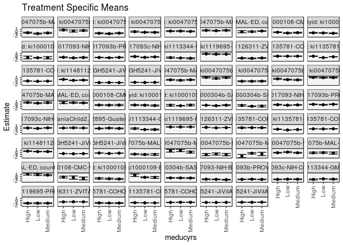

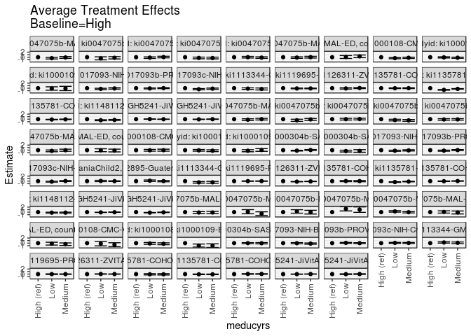

[figure not shown]

## Results Table

### Parameter: TSM

| agecat | studyid | country | intervention_level | baseline_level | estimate | ci_lower | ci_upper |
| --- | --- | --- | --- | --- | --- | --- | --- |
| Birth | ki0047075b-MAL-ED | BANGLADESH | High | NA | -0.8456930 | -1.0792974 | -0.6120885 |
| Birth | ki0047075b-MAL-ED | BANGLADESH | Low | NA | -0.9915747 | -1.2641529 | -0.7189964 |
| Birth | ki0047075b-MAL-ED | BANGLADESH | Medium | NA | -0.9754204 | -1.3840187 | -0.5668221 |
| Birth | ki0047075b-MAL-ED | BRAZIL | High | NA | 0.7304105 | 0.1160307 | 1.3447903 |
| Birth | ki0047075b-MAL-ED | BRAZIL | Low | NA | 0.8984511 | 0.3344378 | 1.4624643 |
| Birth | ki0047075b-MAL-ED | BRAZIL | Medium | NA | 0.1235450 | -0.3178992 | 0.5649891 |
| Birth | ki0047075b-MAL-ED | INDIA | High | NA | -1.0262500 | -1.5172747 | -0.5352253 |
| Birth | ki0047075b-MAL-ED | INDIA | Low | NA | -0.7572222 | -1.2526878 | -0.2617566 |
| Birth | ki0047075b-MAL-ED | INDIA | Medium | NA | -1.0366667 | -1.5769678 | -0.4963655 |
| Birth | ki0047075b-MAL-ED | NEPAL | High | NA | -1.7180000 | -2.4635498 | -0.9724502 |
| Birth | ki0047075b-MAL-ED | NEPAL | Low | NA | -0.4158333 | -0.7761719 | -0.0554948 |
| Birth | ki0047075b-MAL-ED | NEPAL | Medium | NA | -0.7314286 | -1.5015148 | 0.0386577 |
| Birth | ki0047075b-MAL-ED | PERU | High | NA | -0.1630329 | -0.3410039 | 0.0149382 |
| Birth | ki0047075b-MAL-ED | PERU | Low | NA | 0.1205351 | -0.0979986 | 0.3390688 |
| Birth | ki0047075b-MAL-ED | PERU | Medium | NA | -0.1957897 | -0.4082205 | 0.0166411 |
| Birth | ki0047075b-MAL-ED | SOUTH AFRICA | High | NA | -0.1831868 | -0.5084739 | 0.1421003 |
| Birth | ki0047075b-MAL-ED | SOUTH AFRICA | Low | NA | -0.1148282 | -0.4361129 | 0.2064564 |
| Birth | ki0047075b-MAL-ED | SOUTH AFRICA | Medium | NA | -0.3102072 | -0.7969616 | 0.1765471 |
| Birth | ki0047075b-MAL-ED | TANZANIA, UNITED REPUBLIC OF | High | NA | 1.1228571 | 0.7098698 | 1.5358445 |
| Birth | ki0047075b-MAL-ED | TANZANIA, UNITED REPUBLIC OF | Low | NA | 0.9103125 | 0.5359266 | 1.2846984 |
| Birth | ki0047075b-MAL-ED | TANZANIA, UNITED REPUBLIC OF | Medium | NA | 0.6998276 | 0.4307367 | 0.9689185 |
| Birth | ki1000108-CMC-V-BCS-2002 | INDIA | High | NA | -0.2498699 | -0.6591156 | 0.1593757 |
| Birth | ki1000108-CMC-V-BCS-2002 | INDIA | Low | NA | -0.4737466 | -1.2450026 | 0.2975093 |
| Birth | ki1000108-CMC-V-BCS-2002 | INDIA | Medium | NA | -0.8857012 | -1.5472215 | -0.2241809 |
| Birth | ki1000108-IRC | INDIA | High | NA | -0.8769784 | -1.1709391 | -0.5830176 |
| Birth | ki1000108-IRC | INDIA | Low | NA | -1.0117301 | -1.2879065 | -0.7355536 |
| Birth | ki1000108-IRC | INDIA | Medium | NA | -1.1289830 | -1.3981975 | -0.8597685 |
| Birth | ki1000109-EE | PAKISTAN | High | NA | 0.6080000 | 0.0422458 | 1.1737542 |
| Birth | ki1000109-EE | PAKISTAN | Low | NA | -0.3569551 | -0.5627099 | -0.1512003 |
| Birth | ki1000109-EE | PAKISTAN | Medium | NA | -0.3968750 | -0.8274988 | 0.0337488 |

[output cut: 180 more lines]

### Parameter: E(Y)

| agecat | studyid | country | intervention_level | baseline_level | estimate | ci_lower | ci_upper |
| --- | --- | --- | --- | --- | --- | --- | --- |
| Birth | ki0047075b-MAL-ED | BANGLADESH | NA | NA | -0.9109143 | -1.0715205 | -0.7503080 |
| Birth | ki0047075b-MAL-ED | BRAZIL | NA | NA | 0.4029032 | 0.0896793 | 0.7161272 |
| Birth | ki0047075b-MAL-ED | INDIA | NA | NA | -0.9021053 | -1.2132997 | -0.5909108 |
| Birth | ki0047075b-MAL-ED | NEPAL | NA | NA | -0.7791667 | -1.1649642 | -0.3933692 |
| Birth | ki0047075b-MAL-ED | PERU | NA | NA | -0.0520175 | -0.1725298 | 0.0684947 |
| Birth | ki0047075b-MAL-ED | SOUTH AFRICA | NA | NA | -0.1925833 | -0.4053570 | 0.0201904 |
| Birth | ki0047075b-MAL-ED | TANZANIA, UNITED REPUBLIC OF | NA | NA | 0.7997938 | 0.5930740 | 1.0065137 |
| Birth | ki1000108-CMC-V-BCS-2002 | INDIA | NA | NA | -0.4648256 | -0.7643210 | -0.1653302 |
| Birth | ki1000108-IRC | INDIA | NA | NA | -1.0105831 | -1.1973019 | -0.8238643 |
| Birth | ki1000109-EE | PAKISTAN | NA | NA | -0.3333051 | -0.5209779 | -0.1456323 |
| Birth | ki1000304b-SAS-CompFeed | INDIA | NA | NA | -0.6700453 | -0.8474950 | -0.4925957 |
| Birth | ki1017093-NIH-Birth | BANGLADESH | NA | NA | -1.3499217 | -1.4444634 | -1.2553801 |
| Birth | ki1017093b-PROVIDE | BANGLADESH | NA | NA | -1.2984586 | -1.3752758 | -1.2216415 |
| Birth | ki1017093c-NIH-Crypto | BANGLADESH | NA | NA | -1.2441513 | -1.3281130 | -1.1601897 |
| Birth | ki1113344-GMS-Nepal | NEPAL | NA | NA | -1.1182629 | -1.2060675 | -1.0304584 |
| Birth | ki1119695-PROBIT | BELARUS | NA | NA | -1.1448633 | -1.3544229 | -0.9353037 |
| Birth | ki1126311-ZVITAMBO | ZIMBABWE | NA | NA | -0.5152927 | -0.5411678 | -0.4894176 |
| Birth | ki1135781-COHORTS | GUATEMALA | NA | NA | -1.0590508 | -1.1604735 | -0.9576281 |
| Birth | ki1135781-COHORTS | INDIA | NA | NA | -0.9831277 | -1.0164986 | -0.9497568 |
| Birth | ki1135781-COHORTS | PHILIPPINES | NA | NA | -0.7427251 | -0.7890855 | -0.6963647 |
| Birth | kiGH5241-JiVitA-3 | BANGLADESH | NA | NA | -0.7779831 | -0.7969771 | -0.7589891 |
| Birth | kiGH5241-JiVitA-4 | BANGLADESH | NA | NA | -0.6895483 | -0.7419864 | -0.6371102 |
| 6 months | ki0047075b-MAL-ED | BANGLADESH | NA | NA | -0.0723895 | -0.2148128 | 0.0700339 |
| 6 months | ki0047075b-MAL-ED | BRAZIL | NA | NA | 0.9744591 | 0.8094713 | 1.1394470 |
| 6 months | ki0047075b-MAL-ED | INDIA | NA | NA | -0.6859816 | -0.8229470 | -0.5490162 |
| 6 months | ki0047075b-MAL-ED | NEPAL | NA | NA | 0.1223152 | -0.0106456 | 0.2552761 |
| 6 months | ki0047075b-MAL-ED | PERU | NA | NA | 1.0566544 | 0.9348515 | 1.1784573 |
| 6 months | ki0047075b-MAL-ED | SOUTH AFRICA | NA | NA | 0.5421785 | 0.3900443 | 0.6943126 |
| 6 months | ki0047075b-MAL-ED | TANZANIA, UNITED REPUBLIC OF | NA | NA | 0.5536864 | 0.4102695 | 0.6971033 |
| 6 months | ki1000108-CMC-V-BCS-2002 | INDIA | NA | NA | -0.5026766 | -0.6536848 | -0.3516685 |
| 6 months | ki1000108-IRC | INDIA | NA | NA | -0.5989297 | -0.7344491 | -0.4634104 |
| 6 months | ki1000109-EE | PAKISTAN | NA | NA | -0.7785977 | -0.8934940 | -0.6637013 |
| 6 months | ki1000304b-SAS-CompFeed | INDIA | NA | NA | -0.6657084 | -0.8024377 | -0.5289791 |
| 6 months | ki1000304b-SAS-FoodSuppl | INDIA | NA | NA | -1.0121579 | -1.1280429 | -0.8962729 |
| 6 months | ki1017093-NIH-Birth | BANGLADESH | NA | NA | -0.4474038 | -0.5378167 | -0.3569909 |
| 6 months | ki1017093b-PROVIDE | BANGLADESH | NA | NA | -0.1990907 | -0.2817968 | -0.1163845 |
| 6 months | ki1017093c-NIH-Crypto | BANGLADESH | NA | NA | 0.0297622 | -0.0491685 | 0.1086930 |
| 6 months | ki1066203-TanzaniaChild2 | TANZANIA, UNITED REPUBLIC OF | NA | NA | 0.0807224 | 0.0278917 | 0.1335530 |
| 6 months | ki1112895-Guatemala BSC | GUATEMALA | NA | NA | -0.0568833 | -0.1722874 | 0.0585208 |
| 6 months | ki1113344-GMS-Nepal | NEPAL | NA | NA | -0.6087819 | -0.6949591 | -0.5226048 |
| 6 months | ki1119695-PROBIT | BELARUS | NA | NA | 0.5792439 | 0.5193388 | 0.6391490 |
| 6 months | ki1126311-ZVITAMBO | ZIMBABWE | NA | NA | 0.3101107 | 0.2844075 | 0.3358139 |
| 6 months | ki1135781-COHORTS | GUATEMALA | NA | NA | 0.1972718 | 0.1253735 | 0.2691700 |
| 6 months | ki1135781-COHORTS | INDIA | NA | NA | -0.7006307 | -0.7314213 | -0.6698400 |
| 6 months | ki1135781-COHORTS | PHILIPPINES | NA | NA | -0.2938433 | -0.3352064 | -0.2524802 |
| 6 months | ki1148112-LCNI-5 | MALAWI | NA | NA | 0.4399754 | 0.3683855 | 0.5115653 |
| 6 months | kiGH5241-JiVitA-3 | BANGLADESH | NA | NA | -0.5932740 | -0.6128028 | -0.5737451 |
| 6 months | kiGH5241-JiVitA-4 | BANGLADESH | NA | NA | -0.3903558 | -0.4277318 | -0.3529799 |
| 24 months | ki0047075b-MAL-ED | BANGLADESH | NA | NA | -0.7626901 | -0.8991383 | -0.6262418 |
| 24 months | ki0047075b-MAL-ED | BRAZIL | NA | NA | 0.4620139 | 0.2549144 | 0.6691133 |
| 24 months | ki0047075b-MAL-ED | INDIA | NA | NA | -0.9438945 | -1.0682517 | -0.8195372 |
| 24 months | ki0047075b-MAL-ED | NEPAL | NA | NA | -0.3583333 | -0.4767474 | -0.2399193 |
| 24 months | ki0047075b-MAL-ED | PERU | NA | NA | 0.1112042 | -0.0124506 | 0.2348589 |
| 24 months | ki0047075b-MAL-ED | SOUTH AFRICA | NA | NA | 0.4090301 | 0.2879441 | 0.5301161 |
| 24 months | ki0047075b-MAL-ED | TANZANIA, UNITED REPUBLIC OF | NA | NA | 0.0906000 | -0.0489294 | 0.2301294 |
| 24 months | ki1000108-CMC-V-BCS-2002 | INDIA | NA | NA | -0.5571505 | -0.6585247 | -0.4557763 |
| 24 months | ki1000108-IRC | INDIA | NA | NA | -0.7458150 | -0.8368180 | -0.6548120 |
| 24 months | ki1000109-EE | PAKISTAN | NA | NA | -1.0042771 | -1.1523338 | -0.8562205 |
| 24 months | ki1017093-NIH-Birth | BANGLADESH | NA | NA | -0.9115790 | -1.0095022 | -0.8136559 |
| 24 months | ki1017093b-PROVIDE | BANGLADESH | NA | NA | -0.8928670 | -0.9755153 | -0.8102187 |
| 24 months | ki1017093c-NIH-Crypto | BANGLADESH | NA | NA | -0.6103502 | -0.7050157 | -0.5156847 |
| 24 months | ki1113344-GMS-Nepal | NEPAL | NA | NA | -1.1372176 | -1.2263063 | -1.0481290 |
| 24 months | ki1119695-PROBIT | BELARUS | NA | NA | 0.6874295 | 0.5756922 | 0.7991668 |
| 24 months | ki1126311-ZVITAMBO | ZIMBABWE | NA | NA | -1.1825404 | -1.2814625 | -1.0836183 |
| 24 months | ki1135781-COHORTS | GUATEMALA | NA | NA | -0.2765075 | -0.3306839 | -0.2223311 |
| 24 months | ki1135781-COHORTS | INDIA | NA | NA | -0.6386606 | -0.6699072 | -0.6074140 |
| 24 months | ki1135781-COHORTS | PHILIPPINES | NA | NA | -0.6099592 | -0.6467541 | -0.5731643 |
| 24 months | ki1148112-LCNI-5 | MALAWI | NA | NA | -0.0441457 | -0.1265899 | 0.0382985 |
| 24 months | kiGH5241-JiVitA-3 | BANGLADESH | NA | NA | -1.2974744 | -1.3207756 | -1.2741732 |
| 24 months | kiGH5241-JiVitA-4 | BANGLADESH | NA | NA | -1.2243057 | -1.2562915 | -1.1923198 |

### Parameter: ATE

| agecat | studyid | country | intervention_level | baseline_level | estimate | ci_lower | ci_upper |
| --- | --- | --- | --- | --- | --- | --- | --- |
| Birth | ki0047075b-MAL-ED | BANGLADESH | High | High | 0.0000000 | 0.0000000 | 0.0000000 |
| Birth | ki0047075b-MAL-ED | BANGLADESH | Low | High | -0.1458817 | -0.5040070 | 0.2122436 |
| Birth | ki0047075b-MAL-ED | BANGLADESH | Medium | High | -0.1297274 | -0.6033924 | 0.3439376 |
| Birth | ki0047075b-MAL-ED | BRAZIL | High | High | 0.0000000 | 0.0000000 | 0.0000000 |
| Birth | ki0047075b-MAL-ED | BRAZIL | Low | High | 0.1680405 | -0.6479371 | 0.9840182 |
| Birth | ki0047075b-MAL-ED | BRAZIL | Medium | High | -0.6068655 | -1.3562826 | 0.1425515 |
| Birth | ki0047075b-MAL-ED | INDIA | High | High | 0.0000000 | 0.0000000 | 0.0000000 |
| Birth | ki0047075b-MAL-ED | INDIA | Low | High | 0.2690278 | -0.4285333 | 0.9665889 |
| Birth | ki0047075b-MAL-ED | INDIA | Medium | High | -0.0104167 | -0.7405061 | 0.7196728 |
| Birth | ki0047075b-MAL-ED | NEPAL | High | High | 0.0000000 | 0.0000000 | 0.0000000 |
| Birth | ki0047075b-MAL-ED | NEPAL | Low | High | 1.3021667 | 0.4741036 | 2.1302297 |
| Birth | ki0047075b-MAL-ED | NEPAL | Medium | High | 0.9865714 | -0.0852855 | 2.0584284 |
| Birth | ki0047075b-MAL-ED | PERU | High | High | 0.0000000 | 0.0000000 | 0.0000000 |
| Birth | ki0047075b-MAL-ED | PERU | Low | High | 0.2835680 | 0.0012875 | 0.5658484 |
| Birth | ki0047075b-MAL-ED | PERU | Medium | High | -0.0327568 | -0.3120477 | 0.2465340 |
| Birth | ki0047075b-MAL-ED | SOUTH AFRICA | High | High | 0.0000000 | 0.0000000 | 0.0000000 |
| Birth | ki0047075b-MAL-ED | SOUTH AFRICA | Low | High | 0.0683586 | -0.3828373 | 0.5195544 |
| Birth | ki0047075b-MAL-ED | SOUTH AFRICA | Medium | High | -0.1270204 | -0.7077778 | 0.4537369 |
| Birth | ki0047075b-MAL-ED | TANZANIA, UNITED REPUBLIC OF | High | High | 0.0000000 | 0.0000000 | 0.0000000 |
| Birth | ki0047075b-MAL-ED | TANZANIA, UNITED REPUBLIC OF | Low | High | -0.2125446 | -0.7699703 | 0.3448810 |
| Birth | ki0047075b-MAL-ED | TANZANIA, UNITED REPUBLIC OF | Medium | High | -0.4230296 | -0.9159478 | 0.0698887 |
| Birth | ki1000108-CMC-V-BCS-2002 | INDIA | High | High | 0.0000000 | 0.0000000 | 0.0000000 |
| Birth | ki1000108-CMC-V-BCS-2002 | INDIA | Low | High | -0.2238767 | -1.0934500 | 0.6456966 |
| Birth | ki1000108-CMC-V-BCS-2002 | INDIA | Medium | High | -0.6358313 | -1.4160681 | 0.1444055 |
| Birth | ki1000108-IRC | INDIA | High | High | 0.0000000 | 0.0000000 | 0.0000000 |
| Birth | ki1000108-IRC | INDIA | Low | High | -0.1347517 | -0.5015063 | 0.2320029 |
| Birth | ki1000108-IRC | INDIA | Medium | High | -0.2520046 | -0.6160599 | 0.1120507 |
| Birth | ki1000109-EE | PAKISTAN | High | High | 0.0000000 | 0.0000000 | 0.0000000 |
| Birth | ki1000109-EE | PAKISTAN | Low | High | -0.9649551 | -1.5669625 | -0.3629478 |
| Birth | ki1000109-EE | PAKISTAN | Medium | High | -1.0048750 | -1.7158705 | -0.2938795 |

[output cut: 180 more lines]

### Parameter: PAR

| agecat | studyid | country | intervention_level | baseline_level | estimate | ci_lower | ci_upper |
| --- | --- | --- | --- | --- | --- | --- | --- |
| Birth | ki0047075b-MAL-ED | BANGLADESH | High | NA | -0.0652213 | -0.2733733 | 0.1429306 |
| Birth | ki0047075b-MAL-ED | BRAZIL | High | NA | -0.3275073 | -0.8327607 | 0.1777462 |
| Birth | ki0047075b-MAL-ED | INDIA | High | NA | 0.1241447 | -0.3620952 | 0.6103847 |
| Birth | ki0047075b-MAL-ED | NEPAL | High | NA | 0.9388333 | 0.2510235 | 1.6266432 |
| Birth | ki0047075b-MAL-ED | PERU | High | NA | 0.1110153 | -0.0563360 | 0.2783667 |
| Birth | ki0047075b-MAL-ED | SOUTH AFRICA | High | NA | -0.0093965 | -0.3043835 | 0.2855904 |
| Birth | ki0047075b-MAL-ED | TANZANIA, UNITED REPUBLIC OF | High | NA | -0.3230633 | -0.7574306 | 0.1113039 |
| Birth | ki1000108-CMC-V-BCS-2002 | INDIA | High | NA | -0.2149556 | -0.4882764 | 0.0583651 |
| Birth | ki1000108-IRC | INDIA | High | NA | -0.1336047 | -0.3621096 | 0.0949002 |
| Birth | ki1000109-EE | PAKISTAN | High | NA | -0.9413051 | -1.5220076 | -0.3606026 |
| Birth | ki1000304b-SAS-CompFeed | INDIA | High | NA | -0.0392812 | -0.2164986 | 0.1379361 |
| Birth | ki1017093-NIH-Birth | BANGLADESH | High | NA | -0.0864057 | -0.2419389 | 0.0691275 |
| Birth | ki1017093b-PROVIDE | BANGLADESH | High | NA | 0.0105290 | -0.0920087 | 0.1130668 |
| Birth | ki1017093c-NIH-Crypto | BANGLADESH | High | NA | 0.0601985 | -0.0535217 | 0.1739187 |
| Birth | ki1113344-GMS-Nepal | NEPAL | High | NA | 0.2148622 | -0.0107804 | 0.4405049 |
| Birth | ki1119695-PROBIT | BELARUS | High | NA | -0.0001835 | -0.0607594 | 0.0603924 |
| Birth | ki1126311-ZVITAMBO | ZIMBABWE | High | NA | 0.0149749 | -0.0088992 | 0.0388489 |
| Birth | ki1135781-COHORTS | GUATEMALA | High | NA | -0.0520025 | -0.2456621 | 0.1416571 |
| Birth | ki1135781-COHORTS | INDIA | High | NA | -0.0851288 | -0.1708691 | 0.0006116 |
| Birth | ki1135781-COHORTS | PHILIPPINES | High | NA | 0.0438743 | -0.0149503 | 0.1026988 |
| Birth | kiGH5241-JiVitA-3 | BANGLADESH | High | NA | 0.0068445 | -0.0196152 | 0.0333043 |
| Birth | kiGH5241-JiVitA-4 | BANGLADESH | High | NA | 0.0006097 | -0.0739054 | 0.0751248 |
| 6 months | ki0047075b-MAL-ED | BANGLADESH | High | NA | -0.0679853 | -0.2534440 | 0.1174734 |
| 6 months | ki0047075b-MAL-ED | BRAZIL | High | NA | -0.1699407 | -0.3964733 | 0.0565919 |
| 6 months | ki0047075b-MAL-ED | INDIA | High | NA | 0.0012021 | -0.2025896 | 0.2049937 |
| 6 months | ki0047075b-MAL-ED | NEPAL | High | NA | -0.3264942 | -0.5490264 | -0.1039619 |
| 6 months | ki0047075b-MAL-ED | PERU | High | NA | -0.0761247 | -0.2668699 | 0.1146205 |
| 6 months | ki0047075b-MAL-ED | SOUTH AFRICA | High | NA | -0.1498634 | -0.3847925 | 0.0850657 |
| 6 months | ki0047075b-MAL-ED | TANZANIA, UNITED REPUBLIC OF | High | NA | -0.1096470 | -0.6117498 | 0.3924559 |
| 6 months | ki1000108-CMC-V-BCS-2002 | INDIA | High | NA | -0.0197942 | -0.1954140 | 0.1558256 |
| 6 months | ki1000108-IRC | INDIA | High | NA | -0.1191650 | -0.3246587 | 0.0863287 |
| 6 months | ki1000109-EE | PAKISTAN | High | NA | -0.2049880 | -0.5917268 | 0.1817508 |
| 6 months | ki1000304b-SAS-CompFeed | INDIA | High | NA | -0.0670863 | -0.1835607 | 0.0493880 |
| 6 months | ki1000304b-SAS-FoodSuppl | INDIA | High | NA | -0.3393144 | -0.6570473 | -0.0215814 |
| 6 months | ki1017093-NIH-Birth | BANGLADESH | High | NA | -0.1131086 | -0.2639999 | 0.0377827 |
| 6 months | ki1017093b-PROVIDE | BANGLADESH | High | NA | -0.0449961 | -0.1645568 | 0.0745646 |
| 6 months | ki1017093c-NIH-Crypto | BANGLADESH | High | NA | -0.0572632 | -0.1642782 | 0.0497518 |
| 6 months | ki1066203-TanzaniaChild2 | TANZANIA, UNITED REPUBLIC OF | High | NA | -0.0023700 | -0.0944263 | 0.0896863 |
| 6 months | ki1112895-Guatemala BSC | GUATEMALA | High | NA | 0.0570798 | -0.0806619 | 0.1948215 |
| 6 months | ki1113344-GMS-Nepal | NEPAL | High | NA | -0.4503080 | -0.7266595 | -0.1739566 |
| 6 months | ki1119695-PROBIT | BELARUS | High | NA | 0.0137764 | -0.0407488 | 0.0683016 |
| 6 months | ki1126311-ZVITAMBO | ZIMBABWE | High | NA | -0.0583897 | -0.0839483 | -0.0328312 |
| 6 months | ki1135781-COHORTS | GUATEMALA | High | NA | -0.0073561 | -0.1913475 | 0.1766354 |
| 6 months | ki1135781-COHORTS | INDIA | High | NA | -0.2156600 | -0.3119094 | -0.1194107 |
| 6 months | ki1135781-COHORTS | PHILIPPINES | High | NA | 0.0177233 | -0.0361227 | 0.0715693 |
| 6 months | ki1148112-LCNI-5 | MALAWI | High | NA | -0.1282524 | -0.2240369 | -0.0324678 |
| 6 months | kiGH5241-JiVitA-3 | BANGLADESH | High | NA | -0.0424632 | -0.0708166 | -0.0141098 |
| 6 months | kiGH5241-JiVitA-4 | BANGLADESH | High | NA | -0.0957131 | -0.1413594 | -0.0500668 |
| 24 months | ki0047075b-MAL-ED | BANGLADESH | High | NA | -0.1469456 | -0.3338341 | 0.0399429 |
| 24 months | ki0047075b-MAL-ED | BRAZIL | High | NA | -0.1990254 | -0.4761319 | 0.0780812 |
| 24 months | ki0047075b-MAL-ED | INDIA | High | NA | -0.0694087 | -0.2633005 | 0.1244831 |
| 24 months | ki0047075b-MAL-ED | NEPAL | High | NA | -0.2528836 | -0.4996801 | -0.0060872 |
| 24 months | ki0047075b-MAL-ED | PERU | High | NA | -0.0651756 | -0.2563288 | 0.1259775 |
| 24 months | ki0047075b-MAL-ED | SOUTH AFRICA | High | NA | -0.0686948 | -0.2695630 | 0.1321733 |
| 24 months | ki0047075b-MAL-ED | TANZANIA, UNITED REPUBLIC OF | High | NA | 0.2434571 | -0.2583165 | 0.7452308 |
| 24 months | ki1000108-CMC-V-BCS-2002 | INDIA | High | NA | -0.1749572 | -0.2909031 | -0.0590113 |
| 24 months | ki1000108-IRC | INDIA | High | NA | -0.0947521 | -0.2356034 | 0.0460991 |
| 24 months | ki1000109-EE | PAKISTAN | High | NA | -0.1192771 | -0.7609190 | 0.5223648 |
| 24 months | ki1017093-NIH-Birth | BANGLADESH | High | NA | -0.1267417 | -0.2830966 | 0.0296131 |
| 24 months | ki1017093b-PROVIDE | BANGLADESH | High | NA | -0.0049762 | -0.1129699 | 0.1030176 |
| 24 months | ki1017093c-NIH-Crypto | BANGLADESH | High | NA | -0.1830435 | -0.3110342 | -0.0550528 |
| 24 months | ki1113344-GMS-Nepal | NEPAL | High | NA | -0.1953512 | -0.4693641 | 0.0786617 |
| 24 months | ki1119695-PROBIT | BELARUS | High | NA | -0.0964499 | -0.2053611 | 0.0124613 |
| 24 months | ki1126311-ZVITAMBO | ZIMBABWE | High | NA | -0.0016656 | -0.1134034 | 0.1100723 |
| 24 months | ki1135781-COHORTS | GUATEMALA | High | NA | -0.0170215 | -0.1280061 | 0.0939632 |
| 24 months | ki1135781-COHORTS | INDIA | High | NA | -0.3656210 | -0.4641080 | -0.2671339 |
| 24 months | ki1135781-COHORTS | PHILIPPINES | High | NA | -0.0512270 | -0.1021676 | -0.0002864 |
| 24 months | ki1148112-LCNI-5 | MALAWI | High | NA | -0.2173392 | -0.3219378 | -0.1127406 |
| 24 months | kiGH5241-JiVitA-3 | BANGLADESH | High | NA | 0.0034316 | -0.0375073 | 0.0443706 |
| 24 months | kiGH5241-JiVitA-4 | BANGLADESH | High | NA | -0.0267911 | -0.0706770 | 0.0170948 |